# Object Detection with Street View House Numbers

This notebook illustrates how to build a deep CNN using Keras’ functional API to generate multiple outputs: one to predict how many digits are present, and five for the value of each in the order they appear.

## Imports & Settings

```python
import pandas as pd
import numpy as np
from keras.utils import to_categorical
from sklearn.metrics import confusion_matrix
from keras.models import Sequential, Model
from keras.callbacks import ModelCheckpoint
from keras.layers import Conv2D, MaxPooling2D, Flatten, Dense, Input, Dropout, BatchNormalization, Activation
```

## Best Architecture

[Multi-digit Number Recognition from Street View Imagery using Deep Convolutional Neural Networks](https://arxiv.org/abs/1312.6082), Goodfellow, et al, 2014

- eight convolutional hidden layers,
- one locally connected hidden layer
- two densely connected hidden layers.
- the first hidden layer contains maxout units with three filters per unit
- the others contain rectifier units
- the number of units is [48, 64, 128, 160] for the first four layers
- 192 for all other locally connected layers
- the fully connected layers contain 3,072 units each.
- Each convolutional layer includes max pooling and subtractive normalization
- The max pooling window size is 2 × 2.
- The stride alternates between 2 and 1 at each layer, so that half of the layers don’t reduce the spatial size of the representation
- All convolutions use zero padding on the input to preserve representation size.
- The subtractive normalization operates on 3x3 windows and preserves representation size.
- All convolution kernels were of size 5 × 5.
- We trained with dropout applied to all hidden layers but not the input.

The best-performing architecture on the original dataset has eight convolutional layers and two final fully-connected layers. The convolutional layers are similar so that we can define a function to simplify their creation:

```python
def svhn_layer(model, filters, strides, n, input_shape=None):
    if input_shape is not None:
        model.add(Conv2D(filters, kernel_size=5, padding='same', name='CONV{}'.format(n), input_shape=input_shape))
    else:
        model.add(Conv2D(filters, kernel_size=5, padding='same', activation='relu', name='CONV{}'.format(n)))
    model.add(BatchNormalization(name='NORM{}'.format(n)))
    model.add(MaxPooling2D(pool_size=2, strides=strides, name='POOL{}'.format(n)))
    model.add(Dropout(0.2, name='DROP{}'.format(n)))
    return model
```

The entire model combines the Sequential and functional API as follows:

```python
model = Sequential()

svhn_layer(model, 48, 1, n=1, input_shape=(32,32,1))

for i, kernel in enumerate([48, 64, 128, 160] + 3 * [192], 2):
    svhn_layer(model, kernel, strides=2 if i % 2 == 0 else 1, n=i)

model.add(Flatten())
model.add(Dense(3072, name='FC1'))
model.add(Dense(3072, name='FC2'))
y = model.output

n_digits = (Dense(units=6, activation='softmax'))(y)
digit1 = (Dense(units=10, activation='softmax'))(y)
digit2 = (Dense(units=11, activation='softmax'))(y)
digit3 = (Dense(units=11, activation='softmax'))(y)
digit4 = (Dense(units=11, activation='softmax'))(y)
digit5 = (Dense(units=11, activation='softmax'))(y)

svhn_model = Model(inputs=model.input, outputs=[n_digits, digit1, digit2, digit3, digit4, digit5])
```

As a result, the model produces six distinct outputs that we can evaluate.

```python
svhn_model.summary()
```

```
__________________________________________________________________________________________________
Layer (type)                    Output Shape         Param #     Connected to
==================================================================================================
CONV1_input (InputLayer)        (None, 32, 32, 1)    0
__________________________________________________________________________________________________
CONV1 (Conv2D)                  (None, 32, 32, 48)   1248        CONV1_input[0][0]
__________________________________________________________________________________________________
NORM1 (BatchNormalization)      (None, 32, 32, 48)   192         CONV1[0][0]
__________________________________________________________________________________________________
POOL1 (MaxPooling2D)            (None, 31, 31, 48)   0           NORM1[0][0]
__________________________________________________________________________________________________
DROP1 (Dropout)                 (None, 31, 31, 48)   0           POOL1[0][0]
__________________________________________________________________________________________________
CONV2 (Conv2D)                  (None, 31, 31, 48)   57648       DROP1[0][0]
__________________________________________________________________________________________________
NORM2 (BatchNormalization)      (None, 31, 31, 48)   192         CONV2[0][0]
__________________________________________________________________________________________________
POOL2 (MaxPooling2D)            (None, 15, 15, 48)   0           NORM2[0][0]
__________________________________________________________________________________________________
DROP2 (Dropout)                 (None, 15, 15, 48)   0           POOL2[0][0]
__________________________________________________________________________________________________
CONV3 (Conv2D)                  (None, 15, 15, 64)   76864       DROP2[0][0]
__________________________________________________________________________________________________
NORM3 (BatchNormalization)      (None, 15, 15, 64)   256         CONV3[0][0]
__________________________________________________________________________________________________
POOL3 (MaxPooling2D)            (None, 14, 14, 64)   0           NORM3[0][0]
__________________________________________________________________________________________________
DROP3 (Dropout)                 (None, 14, 14, 64)   0           POOL3[0][0]
__________________________________________________________________________________________________
CONV4 (Conv2D)                  (None, 14, 14, 128)  204928      DROP3[0][0]
__________________________________________________________________________________________________
NORM4 (BatchNormalization)      (None, 14, 14, 128)  512         CONV4[0][0]
__________________________________________________________________________________________________
POOL4 (MaxPooling2D)            (None, 7, 7, 128)    0           NORM4[0][0]
__________________________________________________________________________________________________
DROP4 (Dropout)                 (None, 7, 7, 128)    0           POOL4[0][0]
__________________________________________________________________________________________________
CONV5 (Conv2D)                  (None, 7, 7, 160)    512160      DROP4[0][0]
__________________________________________________________________________________________________
NORM5 (BatchNormalization)      (None, 7, 7, 160)    640         CONV5[0][0]
```

[output cut: 36 more lines]

```
__________________________________________________________________________________________________
dense_2 (Dense)                 (None, 10)           30730       FC2[0][0]
__________________________________________________________________________________________________
dense_3 (Dense)                 (None, 11)           33803       FC2[0][0]
__________________________________________________________________________________________________
dense_4 (Dense)                 (None, 11)           33803       FC2[0][0]
__________________________________________________________________________________________________
dense_5 (Dense)                 (None, 11)           33803       FC2[0][0]
__________________________________________________________________________________________________
dense_6 (Dense)                 (None, 11)           33803       FC2[0][0]
==================================================================================================
Total params: 13,686,252
Trainable params: 13,684,204
Non-trainable params: 2,048
__________________________________________________________________________________________________
```

### Get Data

```python
svhn_model.compile(optimizer='adam',
                   loss='categorical_crossentropy',
                   metrics=["accuracy"])
```

```python
with pd.HDFStore('images/svhn/data.h5') as store:
    X_train = store['train/data'].values.reshape(-1, 32, 32, 1)
    y_train = store['train/labels']
    X_test = store['test/data'].values.reshape(-1, 32, 32, 1)
    y_test = store['test/labels']
```

```python
train_digits = [to_categorical(d) for d in y_train.values.T]
test_digits = [to_categorical(d) for d in y_test.values.T]
```

```python
svhn_path = 'models/svhn.cnn.weights.best.hdf5'
```

```python
checkpointer = ModelCheckpoint(filepath=svhn_path,
                               verbose=1,
                               save_best_only=True)
```

```python
epochs = 25
result = svhn_model.fit(x=X_train,
                        y=train_digits,
                        batch_size=32,
                        epochs=epochs,
                        verbose=1,
                        validation_data=(X_test, test_digits),
                        callbacks=[checkpointer])
```

```
Train on 33401 samples, validate on 13068 samples

Epoch 00001: val_loss improved from inf to 7.59463, saving model to models/svhn.cnn.weights.best.hdf5

Epoch 00002: val_loss improved from 7.59463 to 6.27648, saving model to models/svhn.cnn.weights.best.hdf5

Epoch 00003: val_loss did not improve from 6.27648

Epoch 00004: val_loss did not improve from 6.27648

Epoch 00005: val_loss improved from 6.27648 to 5.75069, saving model to models/svhn.cnn.weights.best.hdf5

Epoch 00006: val_loss did not improve from 5.75069

Epoch 00007: val_loss did not improve from 5.75069

Epoch 00008: val_loss did not improve from 5.75069

Epoch 00009: val_loss did not improve from 5.75069

Epoch 00010: val_loss did not improve from 5.75069

Epoch 00011: val_loss did not improve from 5.75069

Epoch 00012: val_loss did not improve from 5.75069

Epoch 00013: val_loss improved from 5.75069 to 5.52721, saving model to models/svhn.cnn.weights.best.hdf5

Epoch 00014: val_loss did not improve from 5.52721

Epoch 00015: val_loss did not improve from 5.52721

Epoch 00016: val_loss did not improve from 5.52721

Epoch 00017: val_loss improved from 5.52721 to 5.32939, saving model to models/svhn.cnn.weights.best.hdf5

Epoch 00018: val_loss improved from 5.32939 to 5.29050, saving model to models/svhn.cnn.weights.best.hdf5

Epoch 00019: val_loss improved from 5.29050 to 5.18384, saving model to models/svhn.cnn.weights.best.hdf5

Epoch 00020: val_loss improved from 5.18384 to 5.09576, saving model to models/svhn.cnn.weights.best.hdf5

Epoch 00021: val_loss improved from 5.09576 to 5.02496, saving model to models/svhn.cnn.weights.best.hdf5

Epoch 00022: val_loss improved from 5.02496 to 5.01586, saving model to models/svhn.cnn.weights.best.hdf5

Epoch 00023: val_loss improved from 5.01586 to 4.42847, saving model to models/svhn.cnn.weights.best.hdf5

Epoch 00024: val_loss improved from 4.42847 to 4.03493, saving model to models/svhn.cnn.weights.best.hdf5

Epoch 00025: val_loss improved from 4.03493 to 3.56102, saving model to models/svhn.cnn.weights.best.hdf5
```

```python
n_digits, digit1, digit2, digit3, digit4, digit5 = svhn_model.predict(X_test, verbose=1)
```

```python
(y_test[0] == np.argmax(n_digits, axis=1)).sum()/len(n_digits)
```

```
0.9206458524640343
```

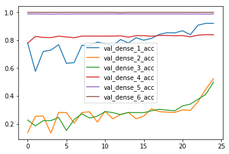

```python
pd.DataFrame(result.history)[['val_dense_{}_acc'.format(i) for i in range(1, 7)]].plot();
```

```python
confusion_matrix(y_true=y_test[0], y_pred=np.argmax(n_digits, axis=1))
```

```
array([[2363,  104,   12,    4,    0],
       [ 183, 7605,  568,    0,    0],
       [  20,   55, 2000,    6,    0],
       [   0,    0,   83,   63,    0],
       [   0,    0,    1,    1,    0]])
```

```python
confusion_matrix(y_true=y_test[1], y_pred=np.argmax(digit1, axis=1))
```

```
array([[   0,   14,    1,    1,    0,    0,    3,    0,    0,    0],
       [   0, 3542,  100,    3,   23,    1,   13,   12,    0,    0],
       [   0,  134, 2137,  222,   15,   20,   30,   97,    2,    0],
       [   0,  112, 1029,  250,   33,  121,   39,   36,    5,    0],
       [   0,  851,   91,    3,  239,    1,   20,   31,    0,    0],
       [   0,   45,  481,  276,    2,  145,   65,   13,   25,    0],
       [   0,  226,   89,   43,   70,   26,  354,   34,   11,    4],
       [   0,  202,  335,   17,   21,    3,   18,  150,    1,    0],
       [   0,   98,  126,   78,   21,   55,  189,   20,   34,    4],
       [   0,   70,  216,   73,   12,   75,   64,   24,   22,    0]])
```

```python
pd.Series(np.argmax(digit1, axis=1)).value_counts()
```

[output not shown]

```python
y_test[0].value_counts(normalize=True)
```

```
2    0.639425
1    0.190006
3    0.159244
4    0.011172
5    0.000153
Name: 0, dtype: float64
```